# Peer Health Shocks and Labor Supply

Evidence from Professional Athletes

Joshua C. Martin

joshua.martin@vanderbilt.edu

Vanderbilt University

October 21, 2024

## Introduction

### Motivation

- Understanding factors that shape **perceptions of risk** and uncertainty has long been a central focus of social science, influencing decisions ranging from savings, investment, insurance, market behavior and price formation while informing theory and policy.
- Research often examines how education, culture, and **social networks** shape preferences and how these channels reduce informational gaps.

## Introduction

### Overview

- I examine the degree to which peers influence risk perceptions, focusing on labor supply decisions of **athletes** whose teammates died from work-related injuries.
- This setting:
  - Identifies peers across time and space,
  - Limits concerns about endogenous peer selection,
  - Allows for the construction of characteristically similar counterfactual groups,
  - Offers insight into wage determination in a relatively free market.

## Introduction

### Findings

- Athletes with a former teammate who died of CTE are 2.2-4.0 percentage points (8-23%) **more likely to retire**.
  - Mechanisms: familiarity, recency, opportunity costs, wage flexibility
  - Placebo: no effect for non-safety-related deaths
  - Treated athletes exhibit higher risk sensitivity, opting for larger signing bonuses and shorter contracts at lower salaries.
- “Treated” workers **value this health shock disamenity at $6M** and need a $1M raise to remain indifferent to exiting.

## Introduction

### Contribution

- **Peers influence risk perceptions** across various domains:
  - Retirement savings (Duflo and Saez 2003)
  - Mortgages and home insurance (Bailey et al. 2018; Hu 2022)
  - Health insurance purchases (Innocenti et al. 2019)
  - Technology adoption (Oster and Thornton 2012)
  - Seat belt use (Robertson, O’Neill, and Wixom 1972)
- I show that risk perception is highly sensitive to peer outcomes, even where this **information is conveyed indirectly and where these risks are highly-publicized**.

## Overview of Literature

- Peer effects are frequently studied in **randomized settings**, such as classrooms and workplaces, with research showing impacts on income, education, health behaviors, social attitudes and productivity (Chetty et al. 2011; Sacerdote 2001; Kremer and Levy 2008; Carrell, Hoekstra, and West 2019; Falk and Ichino 2006; Mas and Moretti 2009; Cohen-Zada, Dayag, and Gershoni 2024).
- In non-competitive labor markets, **injury risks may not be fully reflected in wages** (Fishback and Kantor 1992; Bender and Mridha 2011; Lavetti 2020).
- In sports, wages have been show to be responsive to employer characteristics and location amenities, **injury risk** and the risk or re-injury (Michaelides 2010; Dole and Kassis 2010; Anderson 2022)

## Data

### Sports Reference

- Comprehensive publicly-available **player-by-season** data for professional and collegiate American football and hockey players from 1970-2023
  - university, amateur teams, (athlete) relatives, high school, recruiting rank, city of birth, draft order, age, DOB and (if applicable) DOD, position, accolades, pre-season championship expectations, games played, etc.

## Data

### Worker Productivity

- continuous measures of worker productivity
  - $\approx MP_L$ (relative to replacement worker)
  - “point shares” in hockey, and “approximate value” for football

Productivity and Salary Productivity and Career Length Productivity and Retirement Productivity and Awards Productivity and Age

## Data

### Spotrac

- Privately-available player-by-season data on **player contracts** for professional American football and hockey players from 1980-Present
  - Signing Team
  - When each contract is signed
  - Amount of money in contract
  - Differentiate between salary (variable) and guaranteed (fixed)

## Data

### Analysis Sample

- **2312** unique hockey workers
  - 977 (42%) have complete salary information
  - 538 (23%) are “treated”
- **8817** unique football players
  - 4916 (56%) have complete salary information
  - 1244 (14%) are “treated”

Differences in Contract Data Availability Timeline of Share without Contract Data

## Setting

### CTE

- CTE is an **irreversible neurodegenerative condition** that arises from repeated head impacts over extended periods.
  - Symptoms: motor impairments, difficulties regulating emotion, nerve pain, and dementia, often presenting as having advanced Parkinson’s and Alzheimer’s disease.
  - Treatment: symptom management
  - Age profile: 20s - 80s
  - Diagnosis: post-mortem; analysis of brain tissue

## Setting

### CTE

- CTE has become synonymous with **violent collision sports**, especially American football.
  - Two published academic papers identified the condition in former NFL players (Bennet I. Omalu et al. 2005; Bennet I. Omalu et al. 2006).
- Before the term “CTE,” post-concussive symptoms in athletes were referred to as having one’s “bell rung,” being “**punch drunk**,” or “shell shocked.”
  - These terms implied rare, worst-case outcomes experienced by reckless individuals, with transitory effects.

## Setting

### CTE

- All athletes diagnosed with CTE from 2005-2008 shared **numerous common traits**: long professional careers, disproportionate exposure to repeated head trauma, and violent styles of play.
- This changed in 2009 with the discovery of CTE in Chris Henry.
  - The collision-averse Henry had played competitive football for **fewer than ten years** before he died at age 26.
- In 14 months in 2010-2011, **4 hockey players** (3 of whom were still active professionals) died and were diagnosed with CTE at the ages of 45, 35, 28, and 27. Google Trends Timeline

## Theoretical Framework

### Wokrers’ Maximize Utility

$$U_i = \sum_{t=T_0}^{T} \delta^{t-T_0} \left( d_{ist} \cdot \omega_{ist} + (1 - d_{ist}) \cdot \eta_{ist}
\right)$$

- $U_i$ = utility of individual $i$ over the periods from $t$ to $T$
- $\delta$ = discount factor; reflects time preferences; $0 < \delta < 1$,
- $d_{ist} \in \{0, 1\}$; whether employed in sports
- $\omega_{ist}$ = sport wage
- $\eta_{ist}$ = non-sport wage

## Theoretical Framework

### Non-Sport Wages

$$\eta_{ist} = \mu_i - \theta_{ist}$$

- $\mu$: worker’s human capital value
- $\theta$: reduction in working years due to physical toll from violent sports

$$\theta_{ist} = \gamma_{st} + \epsilon_{ist}$$
- $\gamma$ = known (“inherent”) dangers of the sport

- Full-information of workplace safety $\implies E[\epsilon] = 0$

## Theoretical Framework

### Sport Wages

$$\omega_{ist} = \rho_{st} \cdot \upsilon_{ist} + \beta_{ist} \cdot \theta_{ist}$$

- $\rho$ = market demand
- $\upsilon$ = value of the marginal product of labor (relative to replacement worker)
- $\beta$ = workers’ bargaining power

$$\beta_{ist} = \mu_i + \pi_{st} \cdot \upsilon_{ist}$$
- $\pi$ = strength of collective bargaining agreement

## Theoretical Framework

### Predictions: Full Information

- Workers will remain working in sports if $\omega_{ist} \geq \eta_{ist}$
- **Changes** in the decision to remain in sports:

$$\Delta_{it} (\rho_{ist} + \epsilon_{ist} \cdot (\rho_{ist} + 1)) \geq 0$$

- If $E[\epsilon]=0$, then remain so long as productivity increases:

$$\Delta_{it}( \rho_{ist}) \geq 0$$

Change Operator

## Theoretical Framework

### Predictions: Imperfect Information

- Workers will remain working in sports if $\omega_{ist} \geq \eta_{ist}$

$$\Delta_{it} (\rho_{ist} + \epsilon_{ist} \cdot (\rho_{ist} + 1)) \geq 0$$

- If $E[\epsilon] \neq 0$, then remaining depends upon changes in productivity ($\Delta p \lessgtr -1$)
  - Those with **declining productivity** are more likely to **exit**; cannot internalize risk into wages
  - Those with **rising productivity** are more likely to **stay**; internalize risk into wages (aided by exit of colleagues with declining productivity)

## Empirics

### Identifying Variation (Football, Part I)

| Player | Career | Date of Death | Teammates at τ = -4 |
| --- | --- | --- | --- |
| Justin Strzelczyk | 1990-1998 | 9/30/2004 | 61 |
| Shane Dronett | 1992-2001 | 1/21/2009 | 40 |
| Chris Henry | 2005-2009 | 12/17/2009 | 137 |
| Junior Seau | 1990-2012 | 5/2/2012 | 157 |
| Jovan Belcher | 2009-2012 | 12/1/2012 | 116 |
| Paul Oliver | 2008-2011 | 9/24/2013 | 115 |
| Adrian Robinson | 2012-2013 | 5/16/2015 | 115 |

## Empirics

### Identifying Variation (Football, Part II)

| Player | Career | Date of Death | Teammates at τ = -4 |
| --- | --- | --- | --- |
| Tyler Sash | 2011-2012 | 9/8/2015 | 80 |
| Aaron Hernandez | 2010-2012 | 4/19/2017 | 71 |
| Daniel Te’o-Nesheim | 2010-2013 | 10/29/2017 | 117 |
| George Atkinson | 2014-2016 | 12/2/2019 | 117 |
| Max Tuerk | 2017-2017 | 6/20/2020 | 68 |
| Vincent Jackson | 2005-2016 | 2/15/2021 | 92 |
| Phillip Adams | 2010-2015 | 4/8/2021 | 114 |
| Demaryius Thomas | 2010-2019 | 12/9/2021 | 199 |

## Empirics

### Identifying Variation (Hockey)

| Player | Career | Date of Death | Teammates at τ = -4 |
| --- | --- | --- | --- |
| Bob Probert | 1986-2002 | 7/5/2010 | 53 |
| Derek Boogaard | 2006-2011 | 5/13/2011 | 102 |
| Rick Rypien | 2006-2011 | 8/15/2011 | 92 |
| Wade Belak | 1997-2011 | 8/31/2011 | 151 |
| Steve Montador | 2002-2012 | 2/15/2015 | 141 |
| Marek Svatoš | 2004-2011 | 11/4/2016 | 59 |

## Empirics

### Stacked Difference-in-Differences

- **Stacked DiD**: Centering in Event Time
1. “Slice” **time window**: 9 years (4 seasons pre and 5 seasons post treatment event)
2. Store ID for each treated player so that they **never appear in control group**
3. The data are “stacked” into one dataset with treatment timing that is **centered** at the same relative **event time**

## Empirics

### Two-Way Fixed-Effects Models

**OLS; Average TWFE**

$$Y_{sit} = \alpha_{si} + \delta_{st} + \beta T_{sit} + \epsilon_{sit}$$

**OLS; Dynamic TWFE**

$$Y_{sit} = \alpha_{si} + \delta_{st} + \sum_{\tau=-4}^{-2} \beta_\tau T_{i\tau} + \sum_{\tau = 0}^{4} \gamma_\tau T_{i\tau} + \epsilon_{sit}$$
**Poisson; Average TWFE**

$$log(E[Y_{sit}]) = \alpha_{si} + \delta_{st} + \beta T_{sit} + \epsilon_{sit}$$

## Empirics

### Threats to Identification (Football)

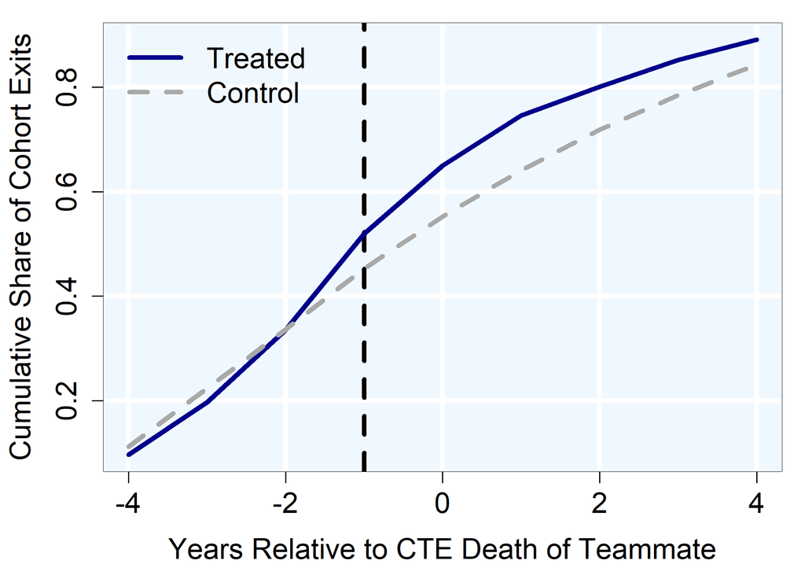

## Empirics

### Threats to Identification (Hockey)

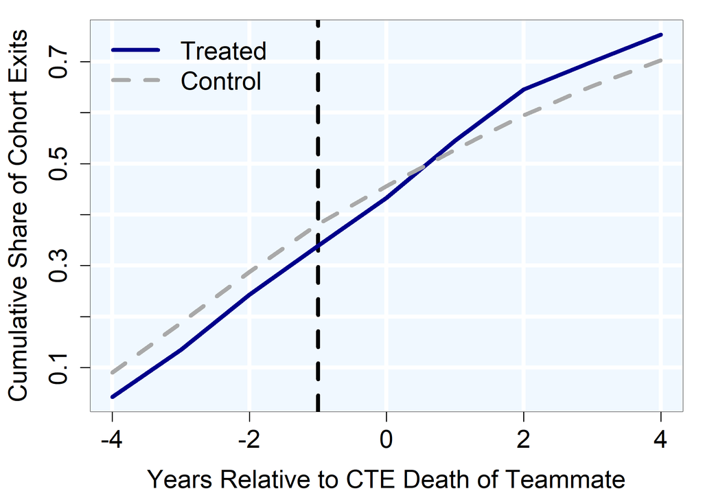

## Empirics

### Matching

- I use the commonly employed **Coarsened Exact Matching** (CEM) technique to adjust for covariate differences between (pre-treatment) treated and control groups.
- CEM:
  - “coarsens” values of covariates (bins them into groups of broader categories a.k.a “strata”) to ensure that both the **mean** and **distribution** of each covariate is similar across groups.
  - **removes bad control units**.
  - **assigns weights** to account for any remaining differences between groups.

## Empirics

### Matching

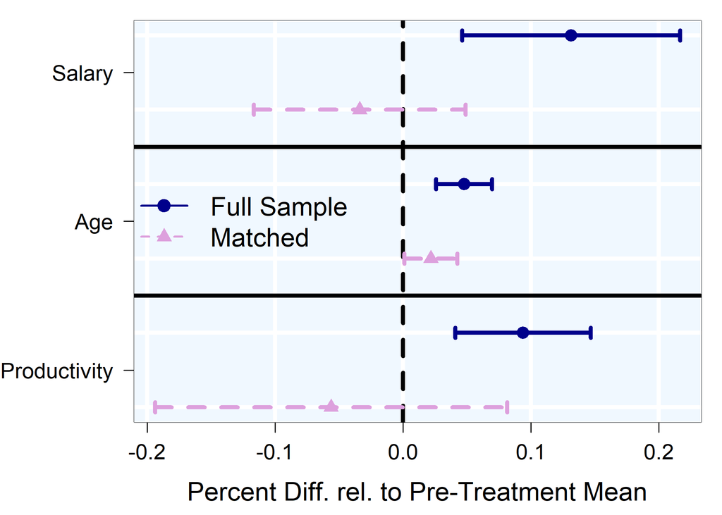

## Results

### Peer Health Shocks & Retirement: Football

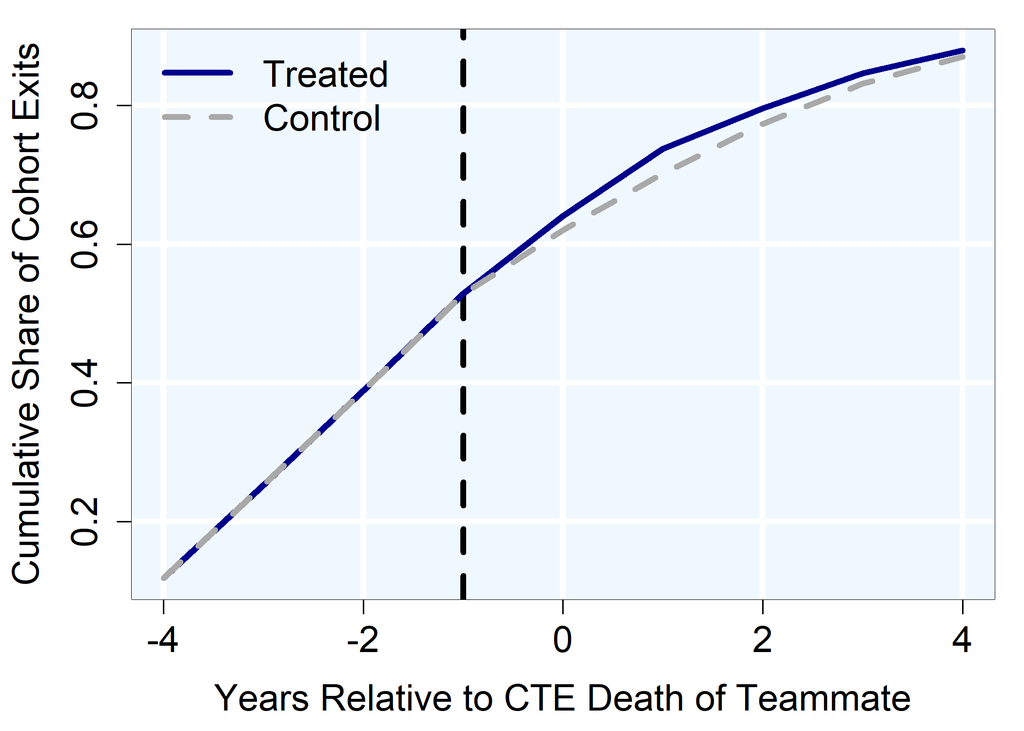

## Results

### Peer Health Shocks & Retirement: Hockey

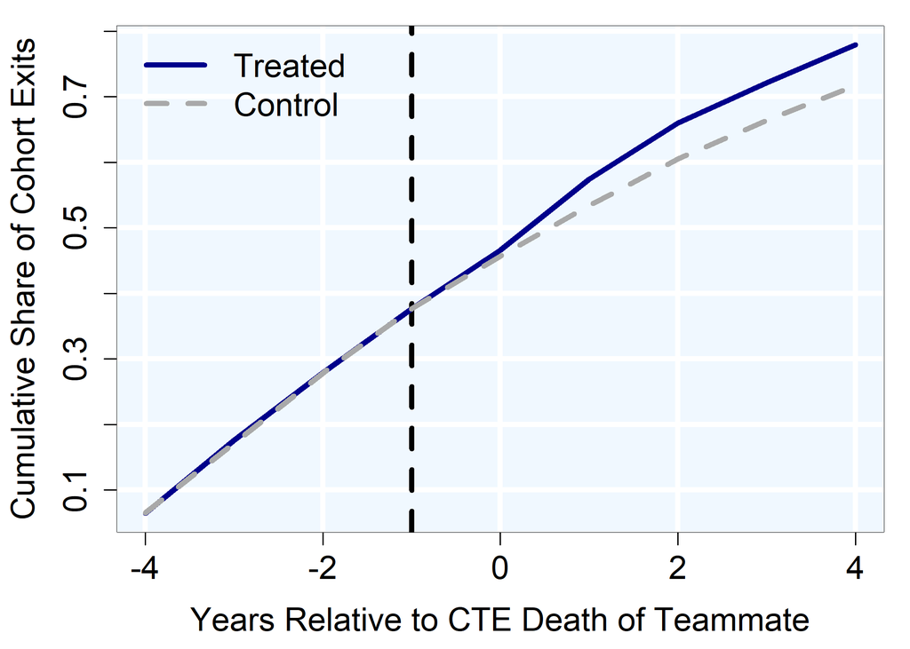

## Results

### Peer Health Shocks & Retirement (Balanced Sample)

| Dependent Variable: Sample: Model: | $\mathbb{1}$(Exit) * 100 Full (1) | $\mathbb{1}$(Exit) * 100 Full (2) | $\mathbb{1}$(Exit) * 100 Matched (3) | $\mathbb{1}$(Exit) * 100 Matched (4) |
| --- | --- | --- | --- | --- |
| CTE (Post) x Teammate | 4.58*** | 1.79** | 2.53*** | 2.24*** |
|  | (0.78) | (0.70) | (0.80) | (0.72) |
| Productivity |  | -13.21*** |  | -13.30*** |
|  |  | (0.08) |  | (0.12) |
| Pre-Treatment Mean | 29.03 | 29.03 | 29.03 | 29.03 |
| % Change | 0.16 | 0.06 | 0.09 | 0.08 |
| Observations | 409,383 | 409,383 | 229,833 | 229,833 |

Unbalanced Sample

## Results

### Peer Health Shocks & Retirement (Balanced Sample; by Sport)

| Dependent Variable: Sport: Sample: Model: | $\mathbb{1}$(Exit) * 100 Hockey Full (1) | $\mathbb{1}$(Exit) * 100 Hockey Matched (2) | $\mathbb{1}$(Exit) * 100 Football Full (3) | $\mathbb{1}$(Exit) * 100 Football Matched (4) |
| --- | --- | --- | --- | --- |
| **Panel A (Balanced Sample)** |  |  |  |  |
| CTE (Post) x Teammate | 7.08*** | 4.42*** | 3.44*** | 1.61* |
|  | (1.39) | (1.41) | (0.94) | (0.98) |
| Pre-Treatment Mean | 22.4 | 22.4 | 32.21 | 32.21 |
| % Change | 0.32 | 0.2 | 0.11 | 0.05 |
| Observations | 74,619 | 52,893 | 334,764 | 176,940 |

Unbalanced Sample

## Results

### Event Studies (by Sport)

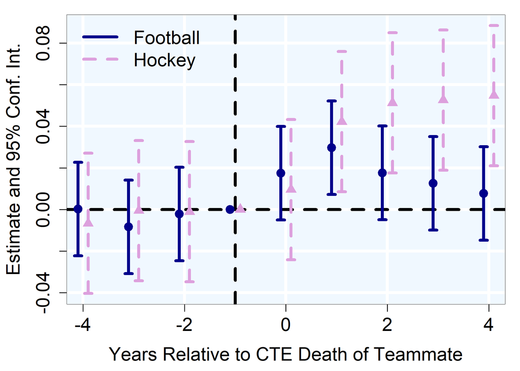

## Hypothesis I

### Familiarity Matters

- The modal **career length** for hockey is over 30% longer than for football while **team sizes** are over 100% smaller
  - This means that the modal hockey player will have been teammates with someone who dies of CTE and will have had greater exposure to them prior to their death

Yearly Turnover by Sport Length of Career by Sport

## Results

### Peer Health Shocks & Retirement (by Time as Teammates)

| Dependent Variable: Model: | $\mathbb{1}$(Exit) * 100 (1) | $\mathbb{1}$(Exit) * 100 (2) | $\mathbb{1}$(Exit) * 100 (3) |  |
| --- | --- | --- | --- | --- |
| **Panel A (Time as Teammates)** |  |  |  |  |
| CTE (Post) x Teammate | 2.53*** | 4.30*** | 4.67*** |  |
|  | (0.80) | (1.22) | (1.69) |  |
| Pre-Treatment Mean | 29.03 | 25.69 | 24.87 |  |
| % Change | 0.09 | 0.17 | 0.19 |  |
| Observations | 229,833 | 218,853 | 215,226 |  |
| Mean Pre-Treatment Age | 27.75 | 28.59 | 29.31 |  |
| Length of Time Teammates ($L$): | $L \geq 1$ | $L \geq 2$ | $L \geq 3$ |  |

Distribution of Years as Teammates

## Results

### Peer Health Shocks & Retirement (by Age)

| Dependent Variable: Model: | $\mathbb{1}$(Exit) * 100 (1) | $\mathbb{1}$(Exit) * 100 (2) | $\mathbb{1}$(Exit) * 100 (3) |  |
| --- | --- | --- | --- | --- |
| **Panel B (Age)** |  |  |  |  |
| CTE (Post) x Teammate | 0.10 | 3.70** | 0.56 |  |
|  | (2.22) | (1.53) | (1.72) |  |
| Pre-Treatment Mean | 10.8 | 17.31 | 36.27 |  |
| % Change | 0.01 | 0.21 | 0.02 |  |
| Observations | 97,794 | 131,022 | 32,643 |  |
| Pre-Treatment Mean Age | 22.36 | 26.03 | 32.25 |  |
| Age Percentile ($P$): | $P < \frac{1}{3}$ | $\frac{1}{3} \leq P < \frac{2}{3}$ | $P \geq \frac{2}{3}$ |  |

## Hypothesis II

### Recency of Treatment Matters

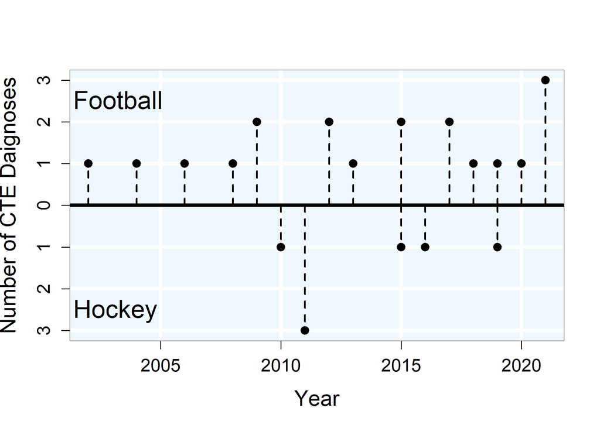

## Hypothesis II

### Recency of Treatment Matters

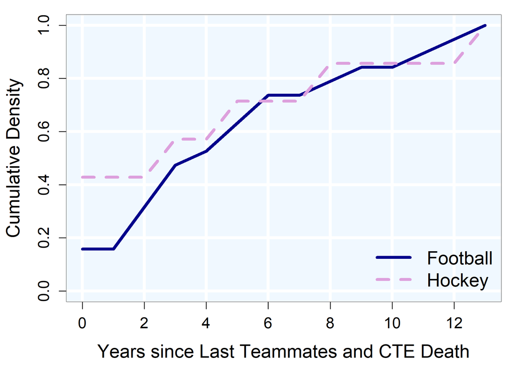

## Results

### Peer Health Shocks & Retirement (Recency of Treatment)

| Dependent Variable: Model: | $\mathbb{1}$(Exit) * 100 (1) | $\mathbb{1}$(Exit) * 100 (2) | $\mathbb{1}$(Exit) * 100 (3) |  |
| --- | --- | --- | --- | --- |
| **Panel A (Recency of Treatment)** |  |  |  |  |
| CTE (Post) x Teammate | 3.14** | 1.78* | 1.91** |  |
|  | (1.45) | (0.96) | (0.88) |  |
| Pre-Treatment Mean | 10.45 | 22.27 | 28.29 |  |
| % Change | 0.3 | 0.08 | 0.07 |  |
| Observations | 95,049 | 202,824 | 219,366 |  |
| Recency of Treatment (D): | $D \leq 2$ | $D \leq 4$ | $D \leq 6$ |  |

Distribution of Last Treatment Timing

## Results

### Peer Health Shocks & Retirements (Recency & 3+ Years Teammates)

| Dependent Variable: Model: | $\mathbb{1}$(Exit) * 100 (1) | $\mathbb{1}$(Exit) * 100 (2) | $\mathbb{1}$(Exit) * 100 (3) |  |
| --- | --- | --- | --- | --- |
| **Panel B (Recency & 3+ Years Teammates)** |  |  |  |  |
| CTE (Post) x Teammate | 7.22* | 4.62* | 3.81* |  |
|  | (4.05) | (2.65) | (2.29) |  |
| Pre-Treatment Mean | 10.45 | 22.27 | 28.29 |  |
| % Change | 0.69 | 0.21 | 0.13 |  |
| Observations | 39,231 | 68,256 | 73,035 |  |
| Recency of Treatment (D): | $D \leq 2$ | $D \leq 4$ | $D \leq 6$ |  |

## Results

### Event Studies (by Contract Detail)

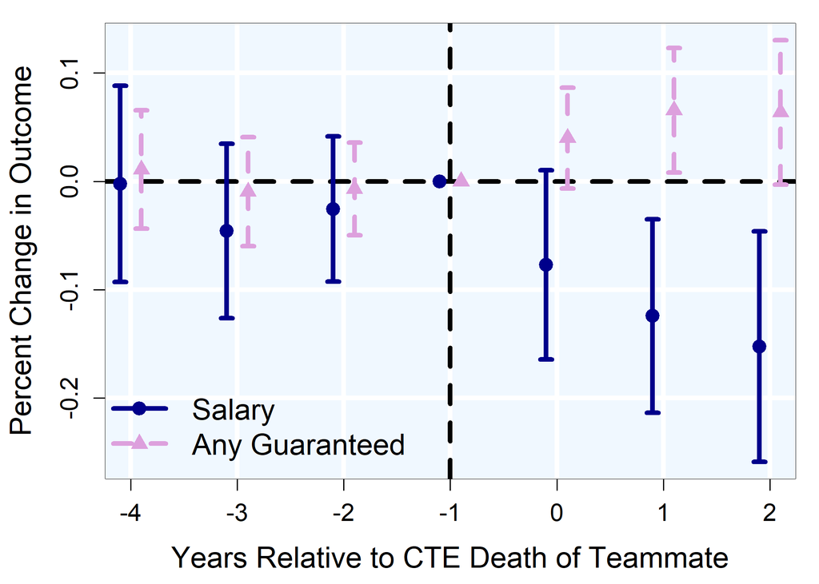

## Results

### Peer Deaths & Retirement: A Placebo Test

| Dependent Variable: Model: | $\mathbb{1}$(Exit) * 100 (1) | $\mathbb{1}$(Exit) * 100 (2) |
| --- | --- | --- |
| Car Accident (Post) x Teammate | -0.01 |  |
|  | (0.01) |  |
| Disease (Post) x Teammate |  | 0.00 |
|  |  | (0.01) |
| Mean of Dep. | 0.19 | 0.19 |
| % Change | -0.06 | 0.00 |
| Observations | 95,533 | 70,891 |

## Hypothesis III

### Bargaining Power & Wage Flexibility Matter

- The collective bargaining agreement covering hockey players **fully guarantees salaries** which comes at the expense of:
  - highly restrictive salary caps (limits on the sum of labor costs)
  - escrow payments (withheld salary; dependent upon league revenues)
- Salary cap per worker in 2024:
  - NFL $\approx \$6.21M$ per worker
  - NHL $\approx \$3.82M$ per worker

  Productivity Distribution by Sport

## Results

### Peer Health Shocks & Retirement (by Opportunity Cost)

| Dependent Variable: Sample: Model: | $\mathbb{1}$(Exit) * 100 Full (1) | $\mathbb{1}$(Exit) * 100 Full (2) | $\mathbb{1}$(Exit) * 100 Hockey (3) | $\mathbb{1}$(Exit) * 100 Football (4) |
| --- | --- | --- | --- | --- |
| *CTE (Post) x Teammate* | 3.59** | 2.48* | 1.53 | 4.08** |
|  | (1.45) | (1.46) | (1.41) | (1.88) |
| *$sinh^{-1}$(Opp. Cost)* | -0.48*** | -0.06*** | -0.09*** | -0.02 |
|  | (0.01) | (0.01) | (0.01) | (0.02) |
| *CTE (Post) x Teammate x $sinh^{-1}$(Opp. Cost)* | -0.37*** | -0.32*** | -0.06 | -0.52*** |
|  | (0.09) | (0.09) | (0.08) | (0.12) |
| Controls: Ct. Total & Length |  | $\checkmark$ | $\checkmark$ | $\checkmark$ |
| Observations | 131,424 | 131,424 | 18,679 | 112,745 |

## Results

### Back-of-the-Envelope Calculation: Compensation and Indifference

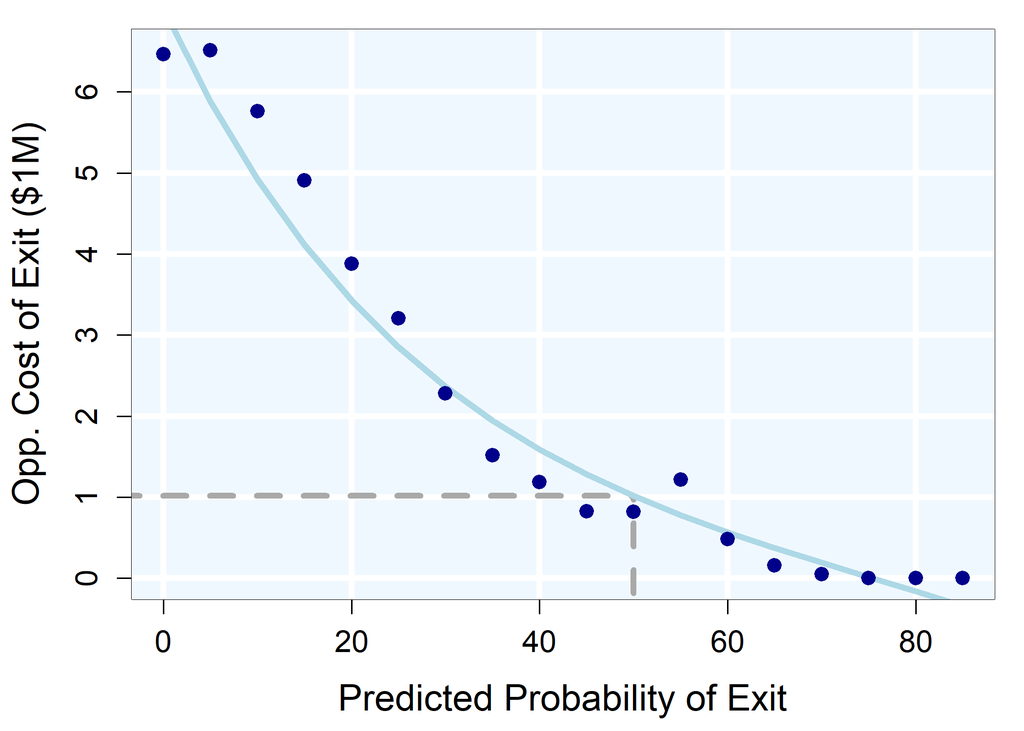

## Conclusion

- I find that workers labor supply is highly elastic with respect to peer health shocks, even in environments where these **risks are widely known** and highly discussed.
  - Familiarity, recency and wage flexibility help explain this finding.
- These findings indicate that **individuals significantly underestimate the utility loss associated with risky behaviors** even in settings where such risks are widely known and discussed.
  - Suggests that public safety policies can provide complementary benefits.

## Thank you!

joshua.martin@vanderbilt.edu

[joshmartinecon.github.io](https://joshmartinecon.github.io/)

[figure not shown]

: JoshMartinEcon

“*Let us suppose that …[a great, distant empire], with all its myriads of inhabitants, was suddenly swallowed up by an earthquake, and let us consider how a man of humanity […], who had no sort of connection with that part of the world, would be affected upon receiving intelligence of this dreadful calamity. He would, I imagine, first of all, express very strongly his sorrow for the misfortune of that unhappy people, he would make many melancholy reflections upon the precariousness of human life, and the vanity of all the labours of man, which could thus be annihilated in a moment…*

*And when all this fine philosophy was over, when all these humane sentiments had been once fairly expressed, he would pursue his business or his pleasure, take his repose or his diversion, with the same ease and tranquillity, as if no such accident had happened. The most frivolous disaster which could befall himself would occasion a more real disturbance.*

*If he was to lose his little finger to-morrow, he would not sleep to-night; but, **provided he never saw them, he will snore with the most profound security over the ruin of a hundred millions of his brethren**, and the destruction of that immense multitude seems plainly an object less interesting to him, than this paltry misfortune of his own.”*

- Adam Smith, *The Theory of Moral Sentiments*

## References

Anderson, Peter. 2022. “Compensating Differentials for the Risk of Reinjury–Lessons from Professional Boxing.” *Journal of Sports Economics*, 15270025221120592.

Bailey, Michael, Ruiqing Cao, Theresa Kuchler, and Johannes Stroebel. 2018. “The Economic Effects of Social Networks: Evidence from the Housing Market.” *Journal of Political Economy* 126 (6): 2224–76.

Bender, Keith A, and Hosne Mridha. 2011. “The Effect of Local Area Unemployment on Compensating Wage Differentials for Injury Risk.” *Southern Economic Journal* 78 (2): 287–307.

Böckerman, Petri, and Pekka Ilmakunnas. 2009. “Job Disamenities, Job Satisfaction, Quit Intentions, and Actual Separations: Putting the Pieces Together.” *Industrial Relations: A Journal of Economy and Society* 48 (1): 73–96.

Carrell, Scott E, Mark Hoekstra, and James E West. 2019. “The Impact of College Diversity on Behavior Toward Minorities.” *American Economic Journal: Economic Policy* 11 (4): 159–82.

Chetty, Raj, John N Friedman, Nathaniel Hilger, Emmanuel Saez, Diane Whitmore Schanzenbach, and Danny Yagan. 2011. “How Does Your Kindergarten Classroom Affect Your Earnings? Evidence from Project STAR.” *The Quarterly Journal of Economics* 126 (4): 1593–1660.

Cohen-Zada, Danny, Itay Dayag, and Naomi Gershoni. 2024. “Effort Peer Effects in Team Production: Evidence from Professional Football.” *Management Science* 70 (4): 2355–81.

Dole, CA, and Mary M Kassis. 2010. “Evidence of a Compensating Wage Differential for NFL Players Who Play on Artificial Turf.” *International Journal of Sport Management and Marketing* 8 (3-4): 254–64.

Duflo, Esther, and Emmanuel Saez. 2003. “The Role of Information and Social Interactions in Retirement Plan Decisions: Evidence from a Randomized Experiment.” *The Quarterly Journal of Economics* 118 (3): 815–42.

Falk, Armin, and Andrea Ichino. 2006. “Clean Evidence on Peer Effects.” *Journal of Labor Economics* 24 (1): 39–57.

Fishback, Price V. 1986. “Workplace Safety During the Progressive Era: Fatal Accidents in Bituminous Coal Mining, 1912–1923.” *Explorations in Economic History* 23 (3): 269–98.

Fishback, Price V, and Shawn Everett Kantor. 1992. “‘Square Deal’ or Raw Deal? Market Compensation for Workplace Disamenities, 1884–1903.” *The Journal of Economic History* 52 (4): 826–48.

Hu, Zhongchen. 2022. “Social Interactions and Households’ Flood Insurance Decisions.” *Journal of Financial Economics* 144 (2): 414–32.

Innocenti, Stefania, Gordon L Clark, Sarah McGill, and Juncal Cuñado. 2019. “The Effect of Past Health Events on Intentions to Purchase Insurance: Evidence from 11 Countries.” *Journal of Economic Psychology* 74: 102204.

Kim, Seung-Wook, and Price V Fishback. 1999. “The Impact of Institutional Change on Compensating Wage Differentials for Accident Risk: South Korea, 1984–1990.” *Journal of Risk and Uncertainty* 18: 231–48.

Kremer, Michael, and Dan Levy. 2008. “Peer Effects and Alcohol Use Among College Students.” *Journal of Economic Perspectives* 22 (3): 189–206.

Lavetti, Kurt. 2020. “The Estimation of Compensating Wage Differentials: Lessons from the Deadliest Catch.” *Journal of Business & Economic Statistics* 38 (1): 165–82.

Mas, Alexandre, and Enrico Moretti. 2009. “Peers at Work.” *American Economic Review* 99 (1): 112–45.

Michaelides, Marios. 2010. “A New Test of Compensating Differences: Evidence on the Importance of Unobserved Heterogeneity.” *Journal of Sports Economics* 11 (5): 475–95.

Omalu, Bennet I., Steven T. DeKosky, Ryan L. Minster, M. Ilyas Kamboh, Ronald L. Hamilton, and Cyril H. Wecht. 2005. “Chronic Traumatic Encephalopathy in a National Football League Player.” *Neurosurgery* 57 (1): 128–34. https://doi.org/10.1227/01.neu.0000163407.92769.ed.

Omalu, Bennet I, Steven T DeKosky, Ronald L Hamilton, Ryan L Minster, M Ilyas Kamboh, Abdulrezak M Shakir, and Cyril H Wecht. 2006. “Chronic Traumatic Encephalopathy in a National Football League Player: Part II.” *Neurosurgery* 59 (5): 1086–93.

Oster, Emily, and Rebecca Thornton. 2012. “Determinants of Technology Adoption: Peer Effects in Menstrual Cup Take-up.” *Journal of the European Economic Association* 10 (6): 1263–93.

Robertson, Leon S, Brian O’Neill, and Charles W Wixom. 1972. “Factors Associated with Observed Safety Belt Use.” *Journal of Health and Social Behavior*, 18–24.

Sacerdote, Bruce. 2001. “Peer Effects with Random Assignment: Results for Dartmouth Roommates.” *The Quarterly Journal of Economics* 116 (2): 681–704.

## Appendix

### Differences in Contract Data Availability

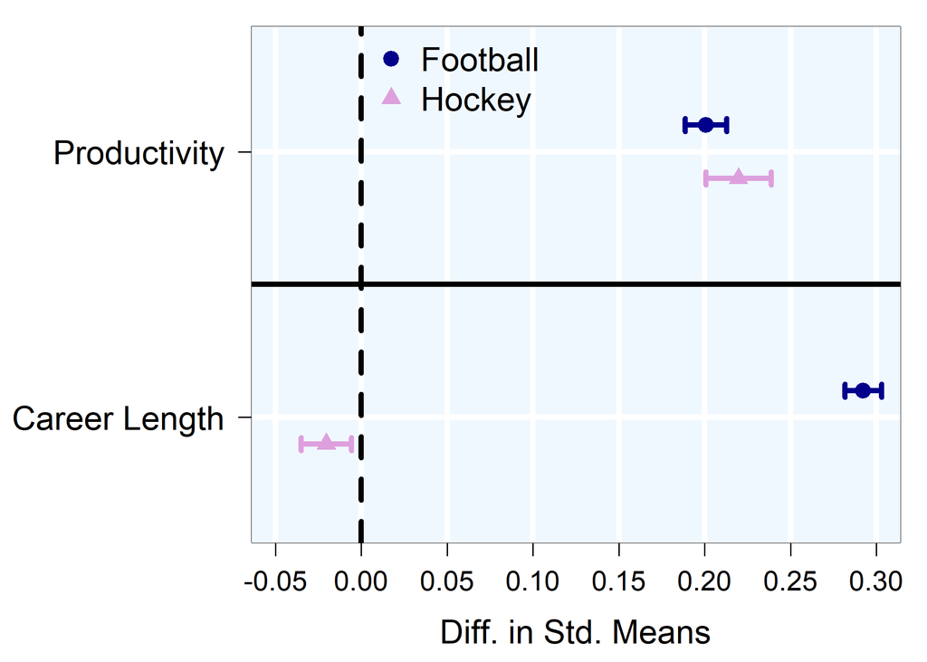

Back

## Appendix

### Share without Contract Data

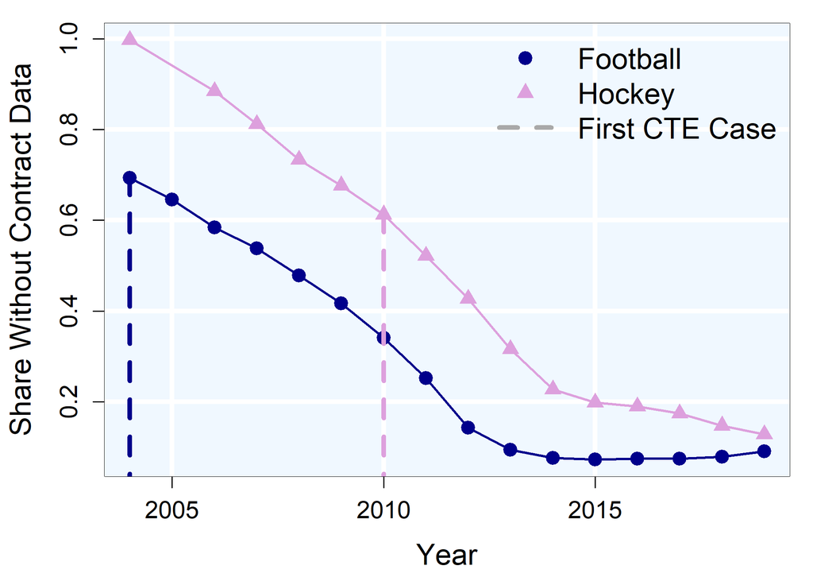

Back

## Appendix

### Productivity and Salary

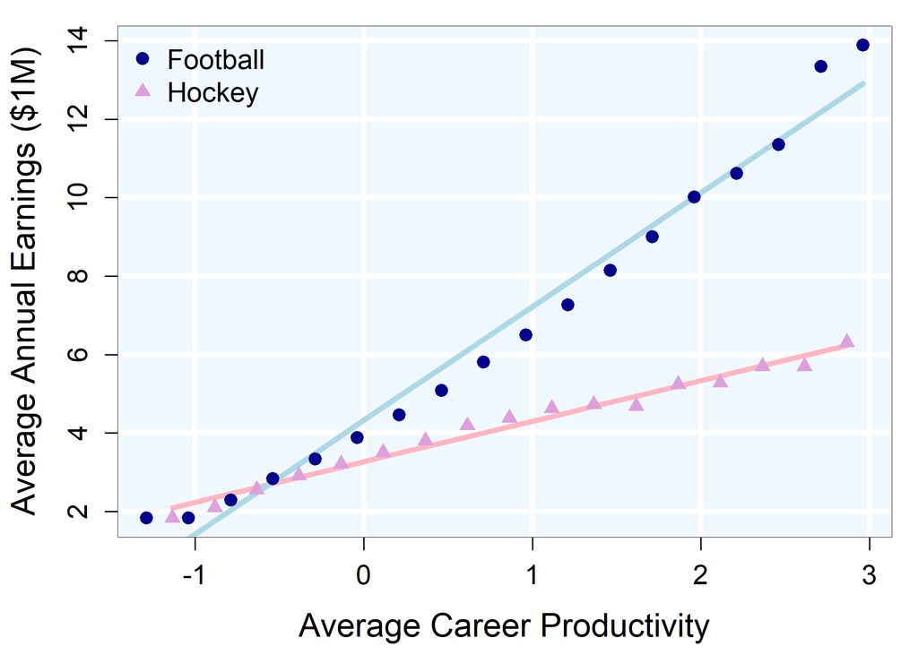

Back

## Appendix

### Productivity and Career Length

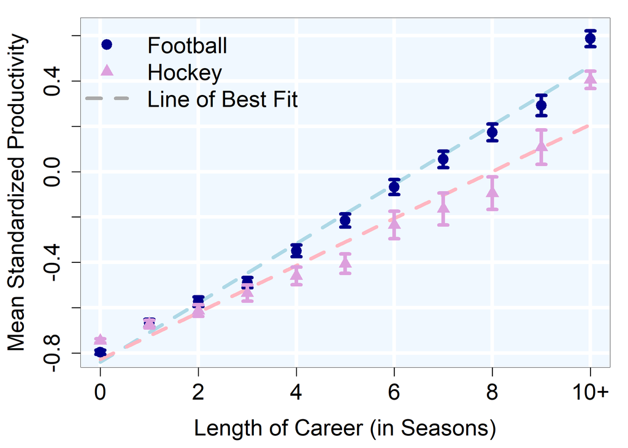

Back

## Appendix

### Productivity relative to Retirement

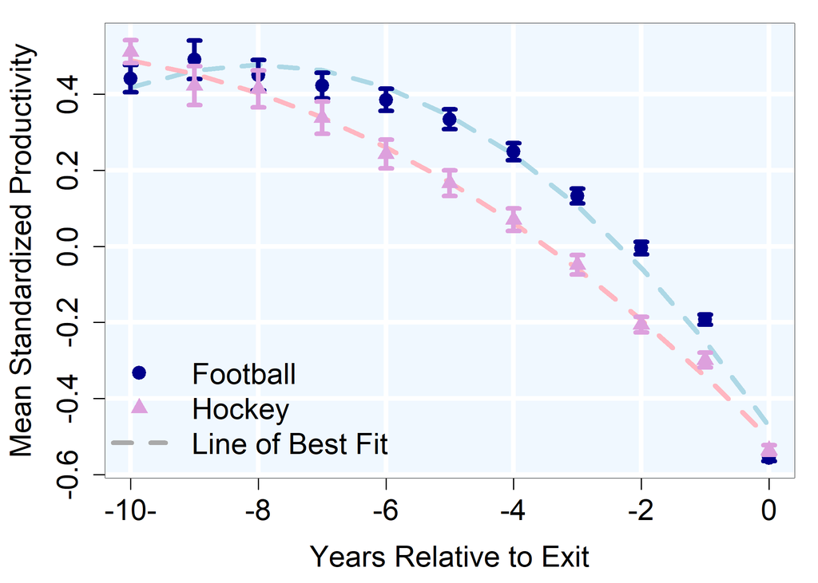

Back

## Appendix

### Productivity and Age

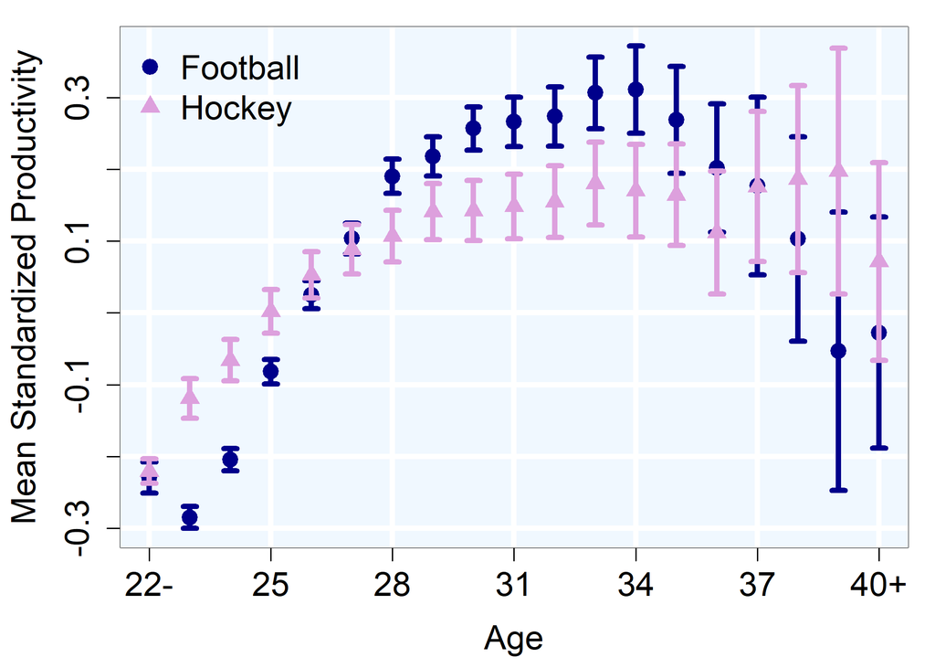

Back

## Appendix

### Productivity and Awards

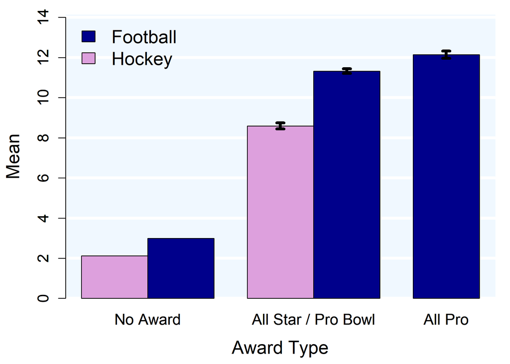

Back

## Appendix

### Google Trends Timeline

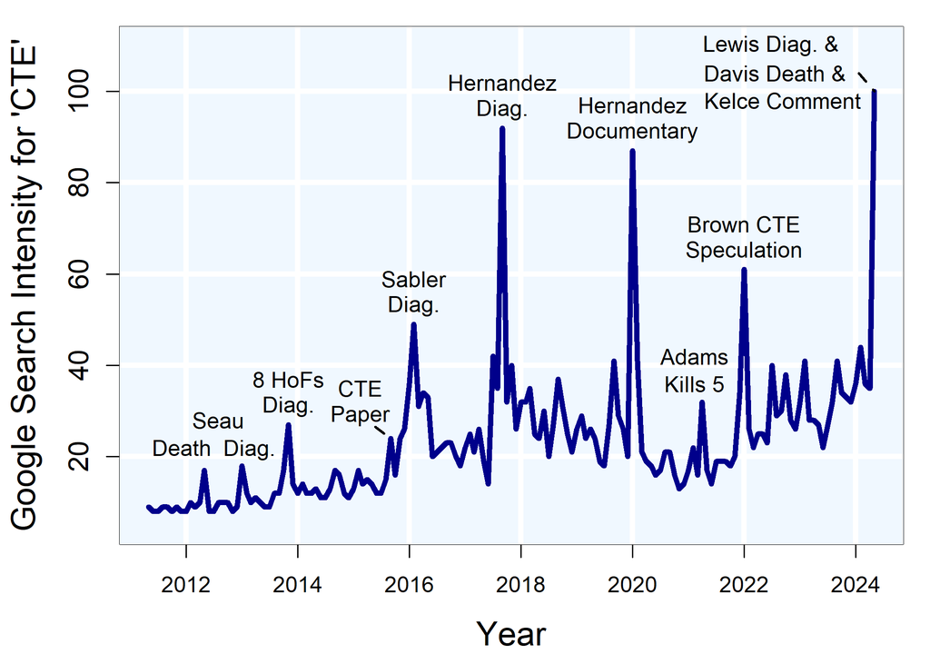

Back

## Appendix

### Distribution of Years as Teammates

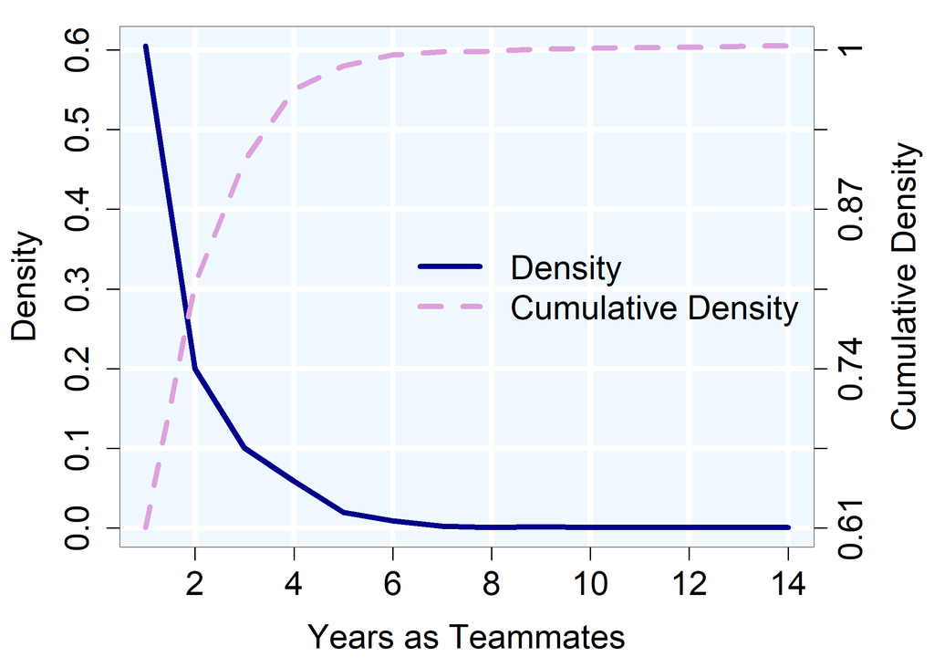

Back

## Appendix

### Distribution of Years since Last Teammates

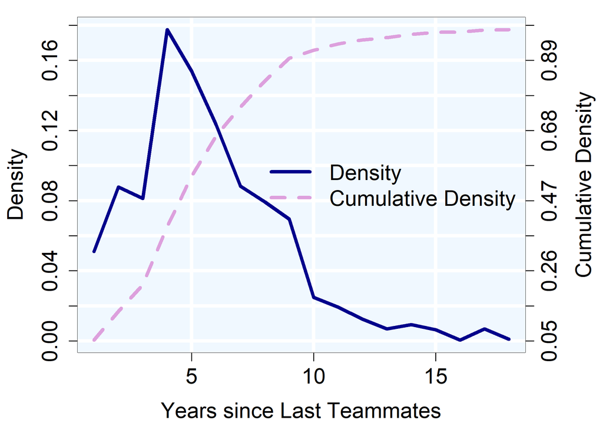

Back

## Appendix

### Peer Health Shocks & Contract Details (Full Sample)

| Dependent Variables: Model: | Total (1) | Guaranteed (2) | Salary (3) | Length (4) |
| --- | --- | --- | --- | --- |
| **Panel A (Full Sample)** |  |  |  |  |
| CTE (Post) x Teammate x New Ct. | 0.07 | 0.29*** | -0.28*** | -0.07* |
|  | (0.07) | (0.07) | (0.06) | (0.04) |
| Length | 0.37*** | 0.23*** | 0.13*** |  |
|  | (0.01) | (0.01) | (0.01) |  |
| Pre-Treatment Mean | 13.84 | 1.17 | 1.76 | 3.84 |
| Change | 1.03 | 0.34 | -0.49 | -0.29 |
| Observations | 77,987 | 61,207 | 77,945 | 78,652 |

## Appendix

### Peer Health Shocks & Contract Details (Balanced Sample)

| Dependent Variables: Model: | Total (1) | Guaranteed (2) | Salary (3) | Length (4) |
| --- | --- | --- | --- | --- |
| **Panel B (Balanced Sample)** |  |  |  |  |
| CTE (Post) x Teammate x New Ct. | 0.02 | 0.22*** | -0.28*** | -0.07* |
|  | (0.07) | (0.07) | (0.06) | (0.04) |
| Length | 0.37*** | 0.23*** | 0.13*** |  |
|  | (0.01) | (0.01) | (0.01) |  |
| Pre-Treatment Mean | 14.38 | 1.21 | 1.86 | 4.03 |
| Change | 0.28 | 0.26 | -0.52 | -0.29 |
| Observations | 52,912 | 44,595 | 52,909 | 53,271 |

## Appendix

### Peer Health Shocks & Contract Details (Hockey)

| Dependent Variables: Model: | Total (1) | Guaranteed (2) | Salary (3) | Length (4) |
| --- | --- | --- | --- | --- |
| **Panel A (Hockey)** |  |  |  |  |
| CTE (Post) x Teammate x New Ct. | -0.01 | -0.08 | -0.04 | 0.08 |
|  | (0.09) | (0.42) | (0.06) | (0.09) |
| Length | 0.28*** | 0.40*** | 0.10*** |  |
|  | (0.02) | (0.07) | (0.01) |  |
| Pre-Treatment Mean | 16.84 | 0.15 | 2.98 | 4.23 |
| Change | -0.21 | -0.01 | -0.12 | 0.33 |
| Observations | 10,980 | 4,093 | 10,972 | 11,278 |

## Appendix

### Peer Health Shocks & Contract Details (Football)

| Dependent Variables: Model: | Total (1) | Guaranteed (2) | Salary (3) | Length (4) |
| --- | --- | --- | --- | --- |
| **Panel B (Football)** |  |  |  |  |
| CTE (Post) x Teammate x New Ct. | 0.13 | 0.29*** | -0.38*** | -0.14*** |
|  | (0.08) | (0.07) | (0.08) | (0.04) |
| Length | 0.39*** | 0.22*** | 0.14*** |  |
|  | (0.01) | (0.01) | (0.01) |  |
| Pre-Treatment Mean | 13.42 | 1.32 | 1.59 | 3.78 |
| Change | 1.8 | 0.38 | -0.61 | -0.55 |
| Observations | 67,007 | 57,114 | 66,973 | 67,374 |

## Appendix

### Change Operator

- Unit fixed-effects: $\Delta X_i = X_{it} - \frac{1}{T} \sum_{\tau = 1}^T x_{i \tau}$
- Time fixed-effects: $\Delta X_i = X_{it} - \frac{1}{I} \sum_{\iota = 1}^I x_{\iota t}$
- For notational simplicity, I denote unit and time fixed-effects as $\Delta_i$ and $\Delta_t$ respectively.

Back

## Overview of Literature

### Peer Effects

- Peer effects are frequently studied in randomized settings, such as classrooms and workplaces, with research showing impacts on:
  - income (Chetty et al. 2011)
  - education (Sacerdote 2001)
  - health behaviors (Kremer and Levy 2008)
  - social attitudes (Carrell, Hoekstra, and West 2019)
- Workplace peer effects are observed in productivity and behavior through social pressure (Falk and Ichino 2006; Mas and Moretti 2009; Cohen-Zada, Dayag, and Gershoni 2024).

Back

## Overview of Literature

### Compensating Wage Differentials

- In non-competitive labor markets, injury risks may not be fully reflected in wages (Fishback and Kantor 1992; Bender and Mridha 2011; Lavetti 2020).
  - This leads to higher quit rates and reduced human capital accumulation (Böckerman and Ilmakunnas 2009).
- Unions increase wages and mitigate compensation costs but were less effective at reducing injury risks (Fishback 1986; Kim and Fishback 1999).

Back

## Overview of Literature

### Compensating Wage Differentials

- In sports, wages have been show to be responsive to:
  - employer characteristics and location amenities (Michaelides 2010)
  - injury risk (Dole and Kassis 2010)
  - risk of re-injury (Anderson 2022)

Back

## Results

### Peer Health Shocks & Retirement (Unbalanced Sample)

| Dependent Variable: Sample: Model: | $\mathbb{1}$(Exit) * 100 Full (1) | $\mathbb{1}$(Exit) * 100 Full (2) | $\mathbb{1}$(Exit) * 100 Matched (3) | $\mathbb{1}$(Exit) * 100 Matched (4) |
| --- | --- | --- | --- | --- |
| CTE (Post) x Teammate | 3.03*** | 1.89* | 4.00*** | 3.97*** |
|  | (1.05) | (1.00) | (1.09) | (1.04) |
| Productivity |  | -10.03*** |  | -10.12*** |
|  |  | (0.12) |  | (0.16) |
| Pre-Treatment Mean | 17.28 | 17.28 | 17.28 | 17.28 |
| % Change | 0.18 | 0.11 | 0.23 | 0.23 |
| Observations | 190,886 | 190,797 | 110,561 | 110,516 |

Back

## Results

### Peer Health Shocks & Retirement (Unbalanced Sample; by Sport)

| Dependent Variable: Sport: Sample: Model: | $\mathbb{1}$(Exit) * 100 Hockey Full (1) | $\mathbb{1}$(Exit) * 100 Hockey Matched (2) | $\mathbb{1}$(Exit) * 100 Football Full (3) | $\mathbb{1}$(Exit) * 100 Football Matched (4) |
| --- | --- | --- | --- | --- |
| **Panel B (Unbalanced Sample)** |  |  |  |  |
| CTE (Post) x Teammate | 5.08*** | 5.15*** | 1.76 | 3.21** |
|  | (1.51) | (1.53) | (1.42) | (1.51) |
| Pre-Treatment Mean | 13.46 | 13.46 | 19.13 | 19.13 |
| % Change | 0.38 | 0.38 | 0.09 | 0.17 |
| Observations | 39,754 | 29,311 | 151,132 | 81,250 |

Back

## Appendix

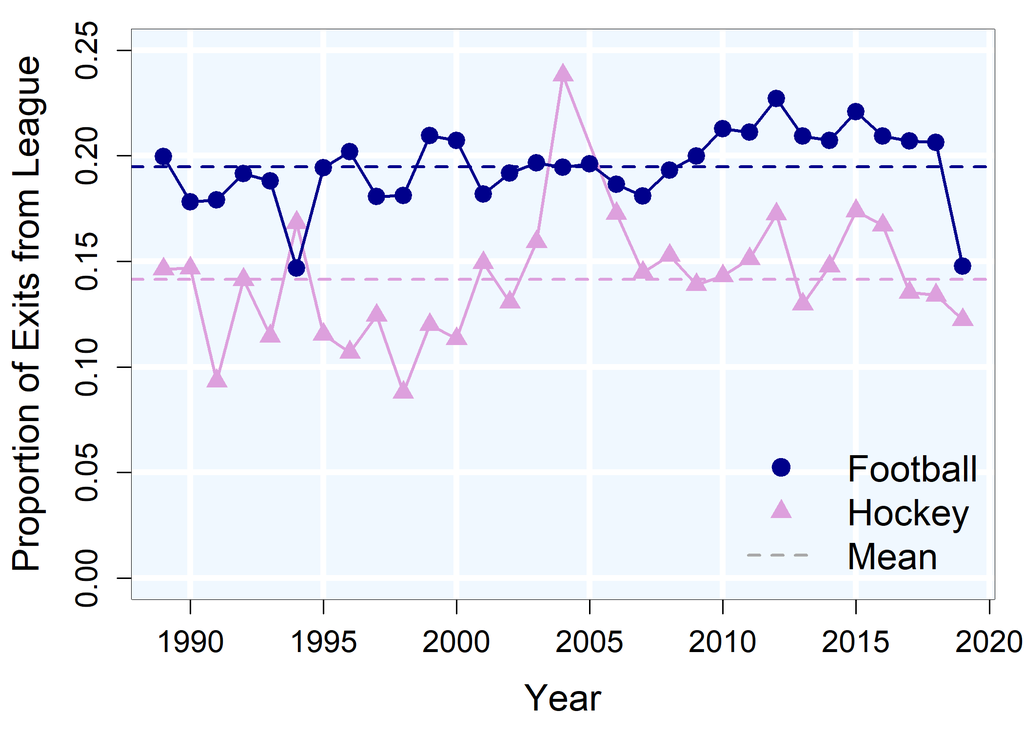

Back

## Appendix

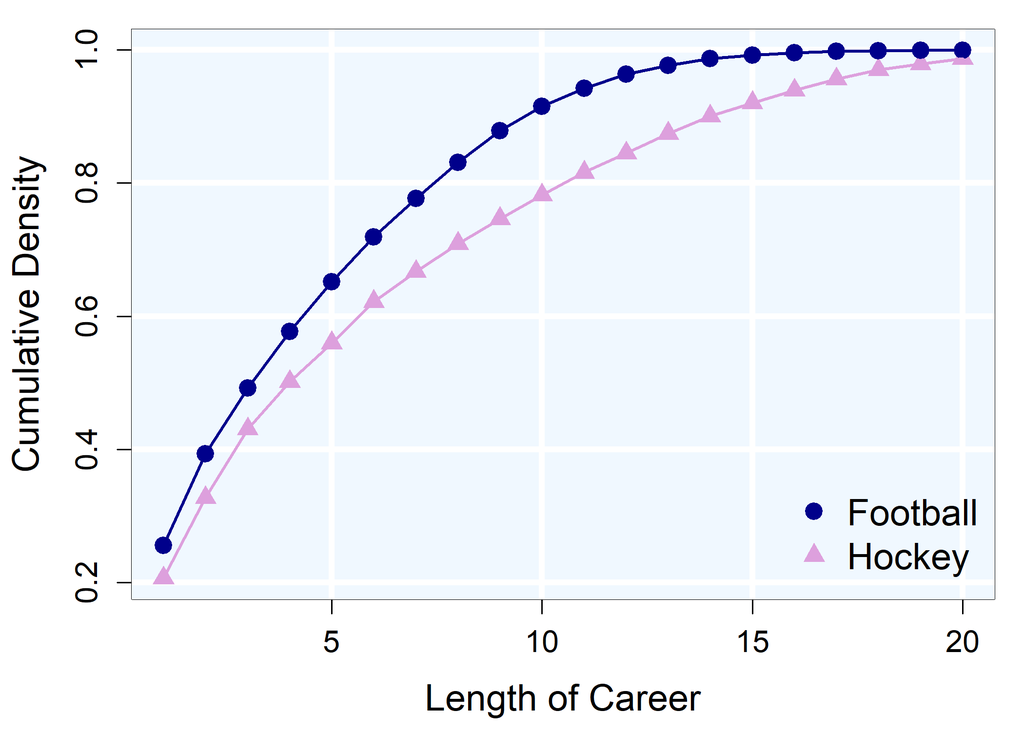

Back

## Appendix

### Distribution of Productivity by Sport

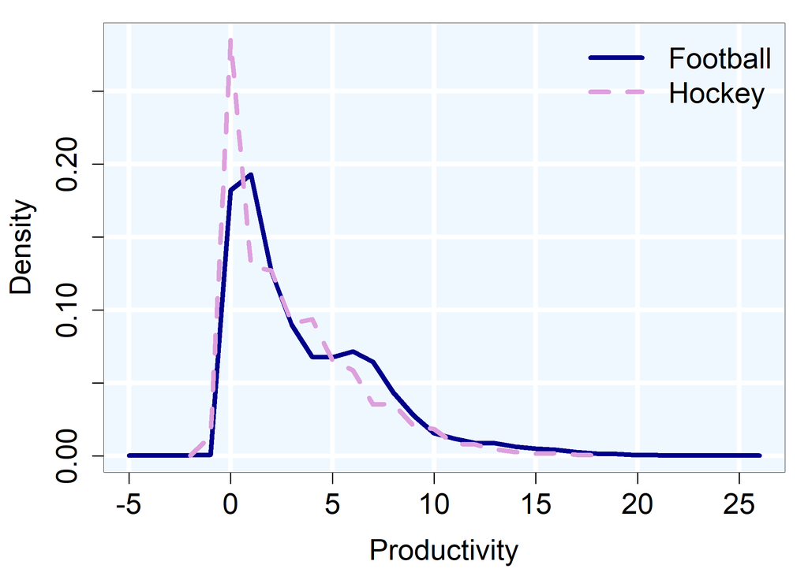

Back